# Pertemuan 3

Natasha Muti Hafiza

2023-09-18

## Impor Data

```r
data_wine <- rio::import("https://raw.githubusercontent.com/natashamuti/mpdw-ako/main/pertemuan%202/data_wine.csv")

t <- data_wine$Year
Xt <- data_wine$Harvested
Yt <- data_wine$Price

dataa <- cbind(t, Xt, Yt)
data <- as.data.frame(dataa)
data
```

```
##       t  Xt      Yt
## 1  2020 579 1325.99
## 2  2019 711 1419.69
## 3  2018 711 1486.84
## 4  2017 683 1479.10
## 5  2016 696 1375.62
## 6  2015 900 1300.00
## 7  2014 900 1391.33
## 8  2013 910 1388.21
## 9  2012 910 1236.92
## 10 2011 900 1350.00
## 11 2010 800 1300.00
## 12 2009 800 1200.00
## 13 2008 600 1100.00
## 14 2007 650 1100.31
```

[output cut: 26 more lines]

## Pembagian Data

```r
#SPLIT DATA
train<-data[1:32,]
test<-data[33:40,]
```

```r
#data time series
train.ts<-ts(train)
test.ts<-ts(test)
data.ts<-ts(data)
```

## Model Koyck

Model Koyck didasarkan pada asumsi bahwa semakin jauh jarak lag peubah independen dari periode sekarang maka semakin kecil pengaruh peubah lag terhadap peubah dependen.

Koyck mengusulkan suatu metode untuk menduga model dinamis distributed lag dengan mengasumsikan bahwa semua koefisien $\beta$ mempunyai tanda sama.

Model kyock merupakan jenis paling umum dari model infinite distributed lag dan juga dikenal sebagai geometric lag

$$y_t=a(1-\lambda)+\beta_0X_t+\beta_1Z_t+\lambda Y_{t-1}+V_t$$

dengan
$$V_t=u_t-\lambda
u_{t-1}$$

```r
#MODEL KOYCK
model.koyck <- koyckDlm(x = train$Xt, y = train$Yt)
summary(model.koyck)
```

```
##
## Call:
## "Y ~ (Intercept) + Y.1 + X.t"
##
## Residuals:
##     Min      1Q  Median      3Q     Max
## -298.07  -65.48  -16.74   55.56  237.04
##
## Coefficients:
##             Estimate Std. Error t value Pr(>|t|)
## (Intercept) 156.0313    97.4514   1.601 0.120574
## Y.1           0.6268     0.1635   3.833 0.000656 ***
## X.t           0.4219     0.2005   2.104 0.044440 *
## ---
## Signif. codes:  0 '***' 0.001 '**' 0.01 '*' 0.05 '.' 0.1 ' ' 1
##
## Residual standard error: 121.9 on 28 degrees of freedom
## Multiple R-Squared: 0.8506,  Adjusted R-squared: 0.8399
## Wald test: 80.21 on 2 and 28 DF,  p-value: 2.562e-12
##
## Diagnostic tests:
## NULL
##
##                             alpha      beta       phi
## Geometric coefficients:  418.1168 0.4218719 0.6268236
```

```r
AIC(model.koyck)
```

```
## [1] 390.6029
```

```r
BIC(model.koyck)
```

```
## [1] 396.3388
```

Dari hasil tersebut, didapat bahwa peubah $x_t$ dan $y_{t-1}$ memiliki nilai $P-Value<0.05$. Hal ini menunjukkan bahwa peubah $x_t$ dan $y_{t-1}$ berpengaruh signifikan terhadap $y$. Adapun model keseluruhannya adalah sebagai berikut

$$\hat{Y_t}=156.0313+0.4219X_t+0.6268Y_{t-1}$$

### Peramalan dan Akurasi

Berikut adalah hasil peramalan y untuk 8 periode kedepan menggunakan model koyck

```r
fore.koyck <- forecast(model = model.koyck, x=test$Xt, h=8)
fore.koyck
```

```
## $forecasts
## [1] 613.5841 597.5930 587.5694 556.8178 537.5420 525.4595 509.4484 496.4592
##
## $call
## forecast.koyckDlm(model = model.koyck, x = test$Xt, h = 8)
##
## attr(,"class")
## [1] "forecast.koyckDlm" "dLagM"
```

```r
mape.koyck <- MAPE(fore.koyck$forecasts, test$Yt)
#akurasi data training
GoF(model.koyck)
```

```
##              n      MAE         MPE       MAPE      sMAPE      MASE     MSE
## model.koyck 31 88.73826 -0.01631401 0.09251133 0.08989046 0.9116726 13415.3
##                 MRAE     GMRAE
## model.koyck 3.591798 0.8758714
```

## Regression with Distributed Lag

### Pemodelan (Lag=10)

```r
model.dlm <- dlm(x = train$Xt,y = train$Yt , q = 10)
summary(model.dlm)
```

```
##
## Call:
## lm(formula = model.formula, data = design)
##
## Residuals:
##     Min      1Q  Median      3Q     Max
## -161.39  -49.44   12.00   56.92  107.41
##
## Coefficients:
##              Estimate Std. Error t value Pr(>|t|)
## (Intercept) 120.03536  100.16632   1.198    0.258
## x.t          -0.40294    0.72007  -0.560    0.588
## x.1           0.14050    0.61058   0.230    0.823
## x.2          -0.04048    0.71541  -0.057    0.956
## x.3           0.19362    0.65229   0.297    0.773
## x.4           0.97158    0.62808   1.547    0.153
## x.5           0.53201    0.61613   0.863    0.408
## x.6          -0.43869    0.51978  -0.844    0.418
## x.7          -0.98691    0.52592  -1.877    0.090 .
## x.8           0.36148    0.48112   0.751    0.470
## x.9           0.01078    0.55269   0.020    0.985
## x.10          0.93673    0.41596   2.252    0.048 *
## ---
## Signif. codes:  0 '***' 0.001 '**' 0.01 '*' 0.05 '.' 0.1 ' ' 1
##
## Residual standard error: 111.9 on 10 degrees of freedom
## Multiple R-squared:  0.909,  Adjusted R-squared:  0.8088
## F-statistic: 9.076 on 11 and 10 DF,  p-value: 0.0007927
##
## AIC and BIC values for the model:
##        AIC     BIC
## 1 278.6515 292.835
```

```r
AIC(model.dlm)
```

```
## [1] 278.6515
```

```r
BIC(model.dlm)
```

```
## [1] 292.835
```

Dari hasil diatas, didapat bahwa $P-value$ dari $x_{t-10}<0.05$, namun $P-value$ dari intercept dan $x_{t}$ hingga $x_{t-9}$ $>0.05$.Hal ini menunjukkan bahwa $x_{t-10}$ berpengaruh signifikan terhadap $y$. Adapun model keseluruhan yang terbentuk adalah sebagai berikut

$$\hat{Y_t}=120.03536+-0.40294X_t+0.14050X_{t-1}+-0.04048X_{t-2}+0.19362X_{t-3}+0.97158X_{t-4}+0.53201X_{t-5}+-0.43869X_{t-6}+-0.98691X_{t-7}+0.36148X_{t-8}+0.01078X_{t-9}+0.93673X_{t-10}$$
### Peramalan dan Akurasi

Berikut merupakan hasil peramalan $y$ untuk 8 periode kedepan

```r
fore.dlm <- forecast(model = model.dlm, x=test$Xt, h=8)
fore.dlm
```

```
## $forecasts
## [1] 535.9518 441.1545 345.3602 339.9379 393.5871 449.4693 409.0757 330.3504
##
## $call
## forecast.dlm(model = model.dlm, x = test$Xt, h = 8)
##
## attr(,"class")
## [1] "forecast.dlm" "dLagM"
```

```r
mape.dlm <- MAPE(fore.dlm$forecasts, test$Yt)
mape.dlm
```

```
## [1] 0.1022283
```

```r
#akurasi data training
GoF(model.dlm)
```

```
##            n      MAE          MPE       MAPE      sMAPE      MASE      MSE
## model.dlm 22 63.41933 -0.009522783 0.08086142 0.07889698 0.5900099 5688.943
##               MRAE    GMRAE
## model.dlm 2.459752 0.728044
```

### *Lag* Optimum

```r
#penentuan lag optimum
finiteDLMauto(formula = Yt ~ Xt,
              data = data.frame(train), q.min = 1, q.max = 14,
              model.type = "dlm", error.type = "AIC", trace = FALSE)
```

```
##    q - k    MASE      AIC      BIC   GMRAE   MBRAE R.Adj.Sq   Ljung-Box
## 14    14 0.21171 213.9708 229.1071 0.16673 0.04749  0.80845 0.001893477
```

Berdasarkan output tersebut, lag optimum didapatkan ketika lag=14. Selanjutnya dilakukan pemodelan untuk lag=14

```r
#model dlm dengan lag optimum
model.dlm2 <- dlm(x = train$Xt,y = train$Yt , q = 14)
summary(model.dlm2)
```

```
##
## Call:
## lm(formula = model.formula, data = design)
##
## Residuals:
##        1        2        3        4        5        6        7        8
##   -5.844   -0.528   14.455    2.418  -23.644   19.370  -26.424   48.399
##        9       10       11       12       13       14       15       16
##  -27.175   -4.366   19.521  -16.622    3.135  -19.058    3.936   58.150
##       17       18
## -102.617   56.892
##
## Coefficients:
##             Estimate Std. Error t value Pr(>|t|)
## (Intercept)  68.5892   155.4366   0.441    0.702
## x.t           6.1091     4.2014   1.454    0.283
## x.1          -4.9350     3.4847  -1.416    0.292
## x.2           2.5002     1.9558   1.278    0.329
## x.3           1.1567     0.8764   1.320    0.318
## x.4           1.5715     1.1018   1.426    0.290
## x.5          -0.2628     0.7613  -0.345    0.763
## x.6          -1.3049     1.2631  -1.033    0.410
## x.7           0.3894     0.9372   0.416    0.718
## x.8          -0.2097     0.6425  -0.326    0.775
## x.9          -3.6709     2.2368  -1.641    0.242
## x.10          2.7201     1.2835   2.119    0.168
## x.11         -1.9848     1.4763  -1.344    0.311
## x.12          1.4503     1.5279   0.949    0.443
## x.13         -0.6842     1.0895  -0.628    0.594
## x.14          0.5853     0.5344   1.095    0.388
##
## Residual standard error: 107.6 on 2 degrees of freedom
## Multiple R-squared:  0.9775, Adjusted R-squared:  0.8085
## F-statistic: 5.783 on 15 and 2 DF,  p-value: 0.1571
##
## AIC and BIC values for the model:
##        AIC      BIC
## 1 213.9708 229.1071
```

```r
AIC(model.dlm2)
```

```
## [1] 213.9708
```

```r
BIC(model.dlm2)
```

```
## [1] 229.1071
```

Dari hasil tersebut tidak diperoleh peubah yang berpengaruh signifikan. Model ini cukup baik dengan nilai R-Square sebesar 97.75%.

Adapun hasil peramalan 8 periode kedepan menggunakan model tersebut adalah sebagai berikut

```r
#peramalan dan akurasi
fore.dlm2 <- forecast(model = model.dlm2, x=test$Xt, h=8)
fore.dlm2
```

```
## $forecasts
## [1] 849.50982 237.44301 415.35185 -91.11280 311.52658  82.95892  24.53277
## [8] 220.96095
##
## $call
## forecast.dlm(model = model.dlm2, x = test$Xt, h = 8)
##
## attr(,"class")
## [1] "forecast.dlm" "dLagM"
```

```r
mape.dlm2<- MAPE(fore.dlm2$forecasts, test$Yt)
#akurasi data training
GoF(model.dlm2)
```

```
##             n      MAE          MPE       MAPE      sMAPE      MASE      MSE
## model.dlm2 18 25.14182 -0.001780185 0.03603638 0.03571315 0.2117132 1287.552
##                 MRAE     GMRAE
## model.dlm2 0.5100118 0.1667342
```

## Model Autoregressive

### Pemodelan

```r
model.ardl <- ardlDlm(x = train$Xt, y = train$Yt, p = 1 , q = 1)
summary(model.ardl)
```

```
##
## Time series regression with "ts" data:
## Start = 2, End = 32
##
## Call:
## dynlm(formula = as.formula(model.text), data = data, start = 1)
##
## Residuals:
##      Min       1Q   Median       3Q      Max
## -301.999  -68.741   -8.234   64.666  243.372
##
## Coefficients:
##             Estimate Std. Error t value Pr(>|t|)
## (Intercept) 124.0793    94.3101   1.316    0.199
## X.t           0.0780     0.3324   0.235    0.816
## X.1           0.2884     0.3255   0.886    0.383
## Y.1           0.6801     0.1459   4.662 7.55e-05 ***
## ---
## Signif. codes:  0 '***' 0.001 '**' 0.01 '*' 0.05 '.' 0.1 ' ' 1
##
## Residual standard error: 121.7 on 27 degrees of freedom
## Multiple R-squared:  0.8563, Adjusted R-squared:  0.8403
## F-statistic: 53.62 on 3 and 27 DF,  p-value: 1.677e-11
```

```r
AIC(model.ardl)
```

```
## [1] 391.3978
```

```r
BIC(model.ardl)
```

```
## [1] 398.5677
```

Hasil di atas menunjukkan bahwa selain peubah $y_{t-1}$, hasil uji t menunjukkan nilai-p pada peubah $\ge0.05$ Hal ini menunjukkan bahwa peubah $y_{t-1}$ berpengaruh signifikan terhadap $y_t$, sementara $x_t$ dan $x_{t-1}$ tidak berpengaruh signifikan terhadap $y_t$. Model keseluruhannya adalah sebagai berikut:

$$\hat{Y}=124.0793+0.0780X_t+0.2884X_{t-1}+0.6801Y_{t-1}$$

### Peramalan dan Akurasi

```r
fore.ardl <- forecast(model = model.ardl, x=test$Xt, h=8)
fore.ardl
```

```
## $forecasts
## [1] 606.7963 590.5265 575.1359 560.1454 533.2230 514.9143 500.9033 485.0607
##
## $call
## forecast.ardlDlm(model = model.ardl, x = test$Xt, h = 8)
##
## attr(,"class")
## [1] "forecast.ardlDlm" "dLagM"
```

Data di atas merupakan hasil peramalan untuk 8 periode ke depan menggunakan Model Autoregressive dengan $p=1$ dan $q=1$.

```r
mape.ardl <- MAPE(fore.ardl$forecasts, test$Yt)
mape.ardl
```

```
## [1] 0.3127651
```

```r
#akurasi data training
GoF(model.ardl)
```

```
##             n      MAE         MPE       MAPE      sMAPE      MASE     MSE
## model.ardl 31 86.44668 -0.01585961 0.08989758 0.08692655 0.8881295 12903.8
##                MRAE     GMRAE
## model.ardl 1.734133 0.7204557
```

### *Lag* Optimum

```r
#penentuan lag optimum
model.ardl.opt <- ardlBoundOrders(data = data.frame(data), ic = "AIC",
                                  formula = Yt ~ Xt )
model.ardl.opt
```

```
## $p
##   Xt
## 1 15
##
## $q
## [1] 3
##
## $Stat.table
##           q = 1    q = 2    q = 3    q = 4    q = 5    q = 6    q = 7    q = 8
## p = 1  470.7707 459.3329 448.1815 438.2206 427.5059 416.8805 405.2404 396.1090
## p = 2  457.4511 459.2138 448.9264 438.8616 427.7306 416.2268 404.2395 394.8072
## p = 3  447.7017 447.7017 449.0461 437.4152 427.1971 415.5262 404.9271 395.1573
## p = 4  435.7865 437.6584 437.6584 437.8910 428.1819 416.7786 406.4943 396.9897
## p = 5  428.2110 430.0048 428.8442 428.8442 429.9192 418.5021 408.0947 398.7622
## p = 6  417.8205 419.8028 417.4282 418.8453 418.8453 418.7073 408.3264 399.2552
## p = 7  397.3479 399.0425 400.6246 402.2552 399.2932 399.2932 398.9764 387.8425
## p = 8  387.4498 389.3861 391.2310 391.9196 387.1865 388.9098 388.9098 389.7706
## p = 9  362.4577 360.9984 359.6474 361.4046 352.3610 347.6403 347.6591 347.6591
## p = 10 354.6535 354.9980 355.0891 357.0134 348.5651 350.5371 352.2014 338.0828
## p = 11 334.2755 331.2995 333.2292 331.9641 321.6588 319.6088 320.4789 321.1541
## p = 12 328.7980 329.4960 328.5347 330.5264 319.3116 320.3420 318.0917 248.2181
## p = 13 313.9206 310.1345 310.6805 308.7385 283.0367 285.0293 285.3421       NA
## p = 14 306.5303 302.4243 282.7680 276.0616 274.8619       NA       NA       NA
## p = 15 251.6538 252.7903 222.7347       NA       NA       NA       NA       NA
##           q = 9   q = 10   q = 11   q = 12   q = 13   q = 14   q = 15
## p = 1  384.1385 375.0922 361.0561 331.1506 321.9127 304.1825 290.1206
## p = 2  383.9172 374.1056 357.7993 329.2154 318.5652 300.8308 289.5961
## p = 3  384.0140 374.3604 359.7728 328.0420 315.6829 302.6435 287.1995
## p = 4  385.3639 375.9971 361.7710 325.7209 314.6196 302.3522 288.8227
## p = 5  386.7164 377.7664 363.7684 324.9440 315.3613 304.3021       NA
## p = 6  388.1710 379.0167 363.3865 326.9359 316.1827 269.6456       NA
## p = 7  375.2722 364.9692 354.2134 326.3426 316.0467       NA       NA
## p = 8  376.4829 366.7780 355.5226 328.3325 299.5454       NA       NA
## p = 9  347.7127 338.0324 316.7032 294.4006       NA       NA       NA
## p = 10 338.0828 340.0155 312.1546 295.3564       NA       NA       NA
## p = 11 320.4042 320.4042 313.6965       NA       NA       NA       NA
## p = 12 250.1860       NA       NA       NA       NA       NA       NA
## p = 13       NA       NA       NA       NA       NA       NA       NA
## p = 14       NA       NA       NA       NA       NA       NA       NA
## p = 15       NA       NA       NA       NA       NA       NA       NA
##
## $min.Stat
## [1] 222.7347
```

```r
min_p=c()
for(i in 1:6){
  min_p[i]=min(model.ardl.opt$Stat.table[[i]])
}
q_opt=which(min_p==min(min_p, na.rm = TRUE))
p_opt=which(model.ardl.opt$Stat.table[[q_opt]] ==
              min(model.ardl.opt$Stat.table[[q_opt]], na.rm = TRUE))
data.frame("q_optimum" = q_opt, "p_optimum" = p_opt,
           "AIC"=model.ardl.opt$min.Stat)
```

```
##   q_optimum p_optimum      AIC
## 1         3        15 222.7347
```

Dari tabel di atas, dapat terlihat bahwa nilai AIC terendah didapat ketika $p=15$ dan $q=3$, yaitu sebesar `222.7347`. Artinya, model autoregressive optimum didapat ketika $p=15$ dan $q=3$.

## Pemodelan DLM & ARDL dengan Library `dynlm`

```r
#sama dengan model dlm q=1
cons_lm1 <- dynlm(Yt ~ Xt+L(Xt),data = train.ts)
#sama dengan model ardl p=1 q=0
cons_lm2 <- dynlm(Yt ~ Xt+L(Yt),data = train.ts)
#sama dengan ardl p=1 q=1
cons_lm3 <- dynlm(Yt ~ Xt+L(Xt)+L(Yt),data = train.ts)
#sama dengan dlm p=2
cons_lm4 <- dynlm(Yt ~ Xt+L(Xt)+L(Xt,2),data = train.ts)
```

### Ringkasan Model

```r
summary(cons_lm1)
```

```
##
## Time series regression with "ts" data:
## Start = 2, End = 32
##
## Call:
## dynlm(formula = Yt ~ Xt + L(Xt), data = train.ts)
##
## Residuals:
##     Min      1Q  Median      3Q     Max
## -217.75 -120.36  -52.66  147.07  254.46
##
## Coefficients:
##             Estimate Std. Error t value Pr(>|t|)
## (Intercept) 482.7891    71.9476   6.710 2.77e-07 ***
## Xt            0.6246     0.4103   1.522    0.139
## L(Xt)         0.4434     0.4271   1.038    0.308
## ---
## Signif. codes:  0 '***' 0.001 '**' 0.01 '*' 0.05 '.' 0.1 ' ' 1
##
## Residual standard error: 160.6 on 28 degrees of freedom
## Multiple R-squared:  0.7406, Adjusted R-squared:  0.7221
## F-statistic: 39.97 on 2 and 28 DF,  p-value: 6.245e-09
```

```r
summary(cons_lm2)
```

```
##
## Time series regression with "ts" data:
## Start = 2, End = 32
##
## Call:
## dynlm(formula = Yt ~ Xt + L(Yt), data = train.ts)
##
## Residuals:
##      Min       1Q   Median       3Q      Max
## -313.959  -71.534   -9.931   63.735  238.648
##
## Coefficients:
##             Estimate Std. Error t value Pr(>|t|)
## (Intercept) 132.9446    93.4178   1.423   0.1657
## Xt            0.3303     0.1708   1.933   0.0633 .
## L(Yt)         0.6933     0.1446   4.796 4.85e-05 ***
## ---
## Signif. codes:  0 '***' 0.001 '**' 0.01 '*' 0.05 '.' 0.1 ' ' 1
##
## Residual standard error: 121.3 on 28 degrees of freedom
## Multiple R-squared:  0.8521, Adjusted R-squared:  0.8415
## F-statistic: 80.66 on 2 and 28 DF,  p-value: 2.395e-12
```

```r
summary(cons_lm3)
```

```
##
## Time series regression with "ts" data:
## Start = 2, End = 32
##
## Call:
## dynlm(formula = Yt ~ Xt + L(Xt) + L(Yt), data = train.ts)
##
## Residuals:
##      Min       1Q   Median       3Q      Max
## -301.999  -68.741   -8.234   64.666  243.372
##
## Coefficients:
##             Estimate Std. Error t value Pr(>|t|)
## (Intercept) 124.0793    94.3101   1.316    0.199
## Xt            0.0780     0.3324   0.235    0.816
## L(Xt)         0.2884     0.3255   0.886    0.383
## L(Yt)         0.6801     0.1459   4.662 7.55e-05 ***
## ---
## Signif. codes:  0 '***' 0.001 '**' 0.01 '*' 0.05 '.' 0.1 ' ' 1
##
## Residual standard error: 121.7 on 27 degrees of freedom
## Multiple R-squared:  0.8563, Adjusted R-squared:  0.8403
## F-statistic: 53.62 on 3 and 27 DF,  p-value: 1.677e-11
```

```r
summary(cons_lm4)
```

```
##
## Time series regression with "ts" data:
## Start = 3, End = 32
##
## Call:
## dynlm(formula = Yt ~ Xt + L(Xt) + L(Xt, 2), data = train.ts)
##
## Residuals:
##     Min      1Q  Median      3Q     Max
## -214.04 -133.66  -17.22  116.04  260.89
##
## Coefficients:
##               Estimate Std. Error t value Pr(>|t|)
## (Intercept) 473.813401  76.260705   6.213 1.42e-06 ***
## Xt            0.353521   0.439148   0.805    0.428
## L(Xt)         0.715482   0.577881   1.238    0.227
## L(Xt, 2)     -0.008113   0.426220  -0.019    0.985
## ---
## Signif. codes:  0 '***' 0.001 '**' 0.01 '*' 0.05 '.' 0.1 ' ' 1
##
## Residual standard error: 158.7 on 26 degrees of freedom
## Multiple R-squared:  0.7525, Adjusted R-squared:  0.7239
## F-statistic: 26.35 on 3 and 26 DF,  p-value: 4.808e-08
```

### SSE

```r
deviance(cons_lm1)
```

```
## [1] 722020.3
```

```r
deviance(cons_lm2)
```

```
## [1] 411652.9
```

```r
deviance(cons_lm3)
```

```
## [1] 400017.9
```

```r
deviance(cons_lm4)
```

```
## [1] 654697.3
```

### Uji Diagnostik

```r
#uji model
if(require("lmtest")) encomptest(cons_lm1, cons_lm2)
```

```
## Encompassing test
##
## Model 1: Yt ~ Xt + L(Xt)
## Model 2: Yt ~ Xt + L(Yt)
## Model E: Yt ~ Xt + L(Xt) + L(Yt)
##           Res.Df Df       F    Pr(>F)
## M1 vs. ME     27 -1 21.7342 7.554e-05 ***
## M2 vs. ME     27 -1  0.7853    0.3833
## ---
## Signif. codes:  0 '***' 0.001 '**' 0.01 '*' 0.05 '.' 0.1 ' ' 1
```

#### Autokorelasi

```r
#durbin watson
dwtest(cons_lm1)
```

```
##
##  Durbin-Watson test
##
## data:  cons_lm1
## DW = 0.75046, p-value = 1.005e-05
## alternative hypothesis: true autocorrelation is greater than 0
```

```r
dwtest(cons_lm2)
```

```
##
##  Durbin-Watson test
##
## data:  cons_lm2
## DW = 2.4177, p-value = 0.8082
## alternative hypothesis: true autocorrelation is greater than 0
```

```r
dwtest(cons_lm3)
```

```
##
##  Durbin-Watson test
##
## data:  cons_lm3
## DW = 2.2511, p-value = 0.648
## alternative hypothesis: true autocorrelation is greater than 0
```

```r
dwtest(cons_lm4)
```

```
##
##  Durbin-Watson test
##
## data:  cons_lm4
## DW = 0.75874, p-value = 1.983e-05
## alternative hypothesis: true autocorrelation is greater than 0
```

#### Heterogenitas

```r
bptest(cons_lm1)
```

```
##
##  studentized Breusch-Pagan test
##
## data:  cons_lm1
## BP = 0.7246, df = 2, p-value = 0.6961
```

```r
bptest(cons_lm2)
```

```
##
##  studentized Breusch-Pagan test
##
## data:  cons_lm2
## BP = 3.7831, df = 2, p-value = 0.1508
```

```r
bptest(cons_lm3)
```

```
##
##  studentized Breusch-Pagan test
##
## data:  cons_lm3
## BP = 3.2298, df = 3, p-value = 0.3575
```

```r
bptest(cons_lm4)
```

```
##
##  studentized Breusch-Pagan test
##
## data:  cons_lm4
## BP = 4.6247, df = 3, p-value = 0.2014
```

#### Kenormalan

```r
shapiro.test(residuals(cons_lm1))
```

```
##
##  Shapiro-Wilk normality test
##
## data:  residuals(cons_lm1)
## W = 0.91186, p-value = 0.01444
```

```r
shapiro.test(residuals(cons_lm2))
```

```
##
##  Shapiro-Wilk normality test
##
## data:  residuals(cons_lm2)
## W = 0.96969, p-value = 0.5105
```

```r
shapiro.test(residuals(cons_lm3))
```

```
##
##  Shapiro-Wilk normality test
##
## data:  residuals(cons_lm3)
## W = 0.97402, p-value = 0.6353
```

```r
shapiro.test(residuals(cons_lm4))
```

```
##
##  Shapiro-Wilk normality test
##
## data:  residuals(cons_lm4)
## W = 0.92623, p-value = 0.03902
```

## Perbandingan Model

```r
akurasi <- matrix(c(mape.koyck, mape.dlm, mape.dlm2, mape.ardl))
row.names(akurasi)<- c("Koyck","DLM 1","DLM 2","Autoregressive")
colnames(akurasi) <- c("MAPE")
akurasi
```

```
##                     MAPE
## Koyck          0.3304396
## DLM 1          0.1022283
## DLM 2          0.6165716
## Autoregressive 0.3127651
```

Berdasarkan nilai MAPE, model paling optimum didapat pada Model DLM 1 karena memiliki nilai MAPE yang terkecil.

### Plot

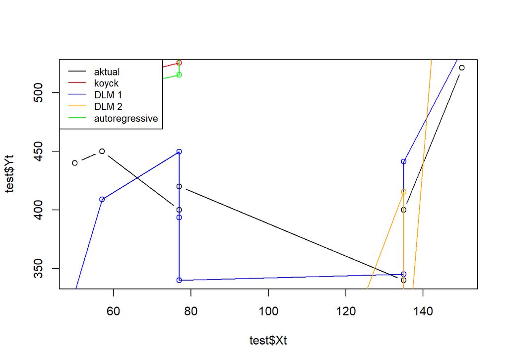

```r
par(mfrow=c(1,1))
plot(test$Xt, test$Yt, type="b", col="black")
points(test$Xt, fore.koyck$forecasts,col="red")
lines(test$Xt, fore.koyck$forecasts,col="red")
points(test$Xt, fore.dlm$forecasts,col="blue")
lines(test$Xt, fore.dlm$forecasts,col="blue")
points(test$Xt, fore.dlm2$forecasts,col="orange")
lines(test$Xt, fore.dlm2$forecasts,col="orange")
points(test$Xt, fore.ardl$forecasts,col="green")
lines(test$Xt, fore.ardl$forecasts,col="green")
legend("topleft",c("aktual", "koyck","DLM 1","DLM 2", "autoregressive"), lty=1, col=c("black","red","blue","orange","green"), cex=0.8)
```

Berdasarkan plot tersebut, terlihat bahwa plot yang paling mendekati data aktualnya adalah Model DLM 1, sehingga dapat disimpulkan model terbaik dalam hal ini adalah model regresi DLM 1